# Udacity Project: Investigate a Dataset

## Titanic Data

Demographic and passenger information from 891 of the 2224 passengers and crew on board the Titanic.

- This project was begun before the project instructions changed. Previously, the project instructions listed only the Titanic data set. Now the instructions list different data sets. I am submitting my original analysis because I had already invested many hours over a few weeks looking into the Titanic dataset. #### Question: What factors made people more likely to survive?

# Data Wrangling

### Load Data from CSV

```python
import pandas as pd

titanic_df = pd.read_csv('titanic_data.csv')
```

```python
# Take a look at the data
titanic_df.head()
```

|  | PassengerId | Survived | Pclass | Name | Sex | Age | SibSp | Parch | Ticket | Fare | Cabin | Embarked |
| --- | --- | --- | --- | --- | --- | --- | --- | --- | --- | --- | --- | --- |
| 0 | 1 | 0 | 3 | Braund, Mr. Owen Harris | male | 22.0 | 1 | 0 | A/5 21171 | 7.2500 | NaN | S |
| 1 | 2 | 1 | 1 | Cumings, Mrs. John Bradley (Florence Briggs Th... | female | 38.0 | 1 | 0 | PC 17599 | 71.2833 | C85 | C |
| 2 | 3 | 1 | 3 | Heikkinen, Miss. Laina | female | 26.0 | 0 | 0 | STON/O2. 3101282 | 7.9250 | NaN | S |
| 3 | 4 | 1 | 1 | Futrelle, Mrs. Jacques Heath (Lily May Peel) | female | 35.0 | 1 | 0 | 113803 | 53.1000 | C123 | S |
| 4 | 5 | 0 | 3 | Allen, Mr. William Henry | male | 35.0 | 0 | 0 | 373450 | 8.0500 | NaN | S |

```python
# Look for rows with missing data:
titanic_df[titanic_df.isnull().any(axis=1)]
```

|  | PassengerId | Survived | Pclass | Name | Sex | Age | SibSp | Parch | Ticket | Fare | Cabin | Embarked |
| --- | --- | --- | --- | --- | --- | --- | --- | --- | --- | --- | --- | --- |
| 0 | 1 | 0 | 3 | Braund, Mr. Owen Harris | male | 22.0 | 1 | 0 | A/5 21171 | 7.2500 | NaN | S |
| 2 | 3 | 1 | 3 | Heikkinen, Miss. Laina | female | 26.0 | 0 | 0 | STON/O2. 3101282 | 7.9250 | NaN | S |
| 4 | 5 | 0 | 3 | Allen, Mr. William Henry | male | 35.0 | 0 | 0 | 373450 | 8.0500 | NaN | S |
| 5 | 6 | 0 | 3 | Moran, Mr. James | male | NaN | 0 | 0 | 330877 | 8.4583 | NaN | Q |
| 7 | 8 | 0 | 3 | Palsson, Master. Gosta Leonard | male | 2.0 | 3 | 1 | 349909 | 21.0750 | NaN | S |
| 8 | 9 | 1 | 3 | Johnson, Mrs. Oscar W (Elisabeth Vilhelmina Berg) | female | 27.0 | 0 | 2 | 347742 | 11.1333 | NaN | S |
| 9 | 10 | 1 | 2 | Nasser, Mrs. Nicholas (Adele Achem) | female | 14.0 | 1 | 0 | 237736 | 30.0708 | NaN | C |
| 12 | 13 | 0 | 3 | Saundercock, Mr. William Henry | male | 20.0 | 0 | 0 | A/5. 2151 | 8.0500 | NaN | S |
| 13 | 14 | 0 | 3 | Andersson, Mr. Anders Johan | male | 39.0 | 1 | 5 | 347082 | 31.2750 | NaN | S |
| 14 | 15 | 0 | 3 | Vestrom, Miss. Hulda Amanda Adolfina | female | 14.0 | 0 | 0 | 350406 | 7.8542 | NaN | S |
| 15 | 16 | 1 | 2 | Hewlett, Mrs. (Mary D Kingcome) | female | 55.0 | 0 | 0 | 248706 | 16.0000 | NaN | S |
| 16 | 17 | 0 | 3 | Rice, Master. Eugene | male | 2.0 | 4 | 1 | 382652 | 29.1250 | NaN | Q |
| 17 | 18 | 1 | 2 | Williams, Mr. Charles Eugene | male | NaN | 0 | 0 | 244373 | 13.0000 | NaN | S |
| 18 | 19 | 0 | 3 | Vander Planke, Mrs. Julius (Emelia Maria Vande... | female | 31.0 | 1 | 0 | 345763 | 18.0000 | NaN | S |
| 19 | 20 | 1 | 3 | Masselmani, Mrs. Fatima | female | NaN | 0 | 0 | 2649 | 7.2250 | NaN | C |
| 20 | 21 | 0 | 2 | Fynney, Mr. Joseph J | male | 35.0 | 0 | 0 | 239865 | 26.0000 | NaN | S |
| 22 | 23 | 1 | 3 | McGowan, Miss. Anna "Annie" | female | 15.0 | 0 | 0 | 330923 | 8.0292 | NaN | Q |
| 24 | 25 | 0 | 3 | Palsson, Miss. Torborg Danira | female | 8.0 | 3 | 1 | 349909 | 21.0750 | NaN | S |
| 25 | 26 | 1 | 3 | Asplund, Mrs. Carl Oscar (Selma Augusta Emilia... | female | 38.0 | 1 | 5 | 347077 | 31.3875 | NaN | S |
| 26 | 27 | 0 | 3 | Emir, Mr. Farred Chehab | male | NaN | 0 | 0 | 2631 | 7.2250 | NaN | C |
| 28 | 29 | 1 | 3 | O'Dwyer, Miss. Ellen "Nellie" | female | NaN | 0 | 0 | 330959 | 7.8792 | NaN | Q |
| 29 | 30 | 0 | 3 | Todoroff, Mr. Lalio | male | NaN | 0 | 0 | 349216 | 7.8958 | NaN | S |
| 30 | 31 | 0 | 1 | Uruchurtu, Don. Manuel E | male | 40.0 | 0 | 0 | PC 17601 | 27.7208 | NaN | C |
| 31 | 32 | 1 | 1 | Spencer, Mrs. William Augustus (Marie Eugenie) | female | NaN | 1 | 0 | PC 17569 | 146.5208 | B78 | C |
| 32 | 33 | 1 | 3 | Glynn, Miss. Mary Agatha | female | NaN | 0 | 0 | 335677 | 7.7500 | NaN | Q |
| 33 | 34 | 0 | 2 | Wheadon, Mr. Edward H | male | 66.0 | 0 | 0 | C.A. 24579 | 10.5000 | NaN | S |
| 34 | 35 | 0 | 1 | Meyer, Mr. Edgar Joseph | male | 28.0 | 1 | 0 | PC 17604 | 82.1708 | NaN | C |
| 35 | 36 | 0 | 1 | Holverson, Mr. Alexander Oskar | male | 42.0 | 1 | 0 | 113789 | 52.0000 | NaN | S |
| 36 | 37 | 1 | 3 | Mamee, Mr. Hanna | male | NaN | 0 | 0 | 2677 | 7.2292 | NaN | C |
| 37 | 38 | 0 | 3 | Cann, Mr. Ernest Charles | male | 21.0 | 0 | 0 | A./5. 2152 | 8.0500 | NaN | S |
| ... | ... | ... | ... | ... | ... | ... | ... | ... | ... | ... | ... | ... |
| 852 | 853 | 0 | 3 | Boulos, Miss. Nourelain | female | 9.0 | 1 | 1 | 2678 | 15.2458 | NaN | C |
| 854 | 855 | 0 | 2 | Carter, Mrs. Ernest Courtenay (Lilian Hughes) | female | 44.0 | 1 | 0 | 244252 | 26.0000 | NaN | S |
| 855 | 856 | 1 | 3 | Aks, Mrs. Sam (Leah Rosen) | female | 18.0 | 0 | 1 | 392091 | 9.3500 | NaN | S |
| 856 | 857 | 1 | 1 | Wick, Mrs. George Dennick (Mary Hitchcock) | female | 45.0 | 1 | 1 | 36928 | 164.8667 | NaN | S |
| 858 | 859 | 1 | 3 | Baclini, Mrs. Solomon (Latifa Qurban) | female | 24.0 | 0 | 3 | 2666 | 19.2583 | NaN | C |
| 859 | 860 | 0 | 3 | Razi, Mr. Raihed | male | NaN | 0 | 0 | 2629 | 7.2292 | NaN | C |
| 860 | 861 | 0 | 3 | Hansen, Mr. Claus Peter | male | 41.0 | 2 | 0 | 350026 | 14.1083 | NaN | S |
| 861 | 862 | 0 | 2 | Giles, Mr. Frederick Edward | male | 21.0 | 1 | 0 | 28134 | 11.5000 | NaN | S |
| 863 | 864 | 0 | 3 | Sage, Miss. Dorothy Edith "Dolly" | female | NaN | 8 | 2 | CA. 2343 | 69.5500 | NaN | S |
| 864 | 865 | 0 | 2 | Gill, Mr. John William | male | 24.0 | 0 | 0 | 233866 | 13.0000 | NaN | S |
| 865 | 866 | 1 | 2 | Bystrom, Mrs. (Karolina) | female | 42.0 | 0 | 0 | 236852 | 13.0000 | NaN | S |
| 866 | 867 | 1 | 2 | Duran y More, Miss. Asuncion | female | 27.0 | 1 | 0 | SC/PARIS 2149 | 13.8583 | NaN | C |
| 868 | 869 | 0 | 3 | van Melkebeke, Mr. Philemon | male | NaN | 0 | 0 | 345777 | 9.5000 | NaN | S |
| 869 | 870 | 1 | 3 | Johnson, Master. Harold Theodor | male | 4.0 | 1 | 1 | 347742 | 11.1333 | NaN | S |
| 870 | 871 | 0 | 3 | Balkic, Mr. Cerin | male | 26.0 | 0 | 0 | 349248 | 7.8958 | NaN | S |
| 873 | 874 | 0 | 3 | Vander Cruyssen, Mr. Victor | male | 47.0 | 0 | 0 | 345765 | 9.0000 | NaN | S |
| 874 | 875 | 1 | 2 | Abelson, Mrs. Samuel (Hannah Wizosky) | female | 28.0 | 1 | 0 | P/PP 3381 | 24.0000 | NaN | C |
| 875 | 876 | 1 | 3 | Najib, Miss. Adele Kiamie "Jane" | female | 15.0 | 0 | 0 | 2667 | 7.2250 | NaN | C |
| 876 | 877 | 0 | 3 | Gustafsson, Mr. Alfred Ossian | male | 20.0 | 0 | 0 | 7534 | 9.8458 | NaN | S |
| 877 | 878 | 0 | 3 | Petroff, Mr. Nedelio | male | 19.0 | 0 | 0 | 349212 | 7.8958 | NaN | S |
| 878 | 879 | 0 | 3 | Laleff, Mr. Kristo | male | NaN | 0 | 0 | 349217 | 7.8958 | NaN | S |
| 880 | 881 | 1 | 2 | Shelley, Mrs. William (Imanita Parrish Hall) | female | 25.0 | 0 | 1 | 230433 | 26.0000 | NaN | S |
| 881 | 882 | 0 | 3 | Markun, Mr. Johann | male | 33.0 | 0 | 0 | 349257 | 7.8958 | NaN | S |
| 882 | 883 | 0 | 3 | Dahlberg, Miss. Gerda Ulrika | female | 22.0 | 0 | 0 | 7552 | 10.5167 | NaN | S |
| 883 | 884 | 0 | 2 | Banfield, Mr. Frederick James | male | 28.0 | 0 | 0 | C.A./SOTON 34068 | 10.5000 | NaN | S |
| 884 | 885 | 0 | 3 | Sutehall, Mr. Henry Jr | male | 25.0 | 0 | 0 | SOTON/OQ 392076 | 7.0500 | NaN | S |
| 885 | 886 | 0 | 3 | Rice, Mrs. William (Margaret Norton) | female | 39.0 | 0 | 5 | 382652 | 29.1250 | NaN | Q |
| 886 | 887 | 0 | 2 | Montvila, Rev. Juozas | male | 27.0 | 0 | 0 | 211536 | 13.0000 | NaN | S |
| 888 | 889 | 0 | 3 | Johnston, Miss. Catherine Helen "Carrie" | female | NaN | 1 | 2 | W./C. 6607 | 23.4500 | NaN | S |
| 890 | 891 | 0 | 3 | Dooley, Mr. Patrick | male | 32.0 | 0 | 0 | 370376 | 7.7500 | NaN | Q |

708 rows × 12 columns

708 of the 891 rows contain missing values. Nearly all missing values occur in the **Cabin** column. Some also appear in the **Age** column. Looking at the counts of non-null values below, we can also see that there are two missing values in the **Embarked** column:

```python
# Look for missing values
titanic_df.count()
```

```
PassengerId    891
Survived       891
Pclass         891
Name           891
Sex            891
Age            714
SibSp          891
Parch          891
Ticket         891
Fare           891
Cabin          204
Embarked       889
dtype: int64
```

These are the two passengers with unknown embark locations:

```python
# Find passengers with unknown embark locations:
titanic_df[titanic_df['Embarked'].isnull()]
```

|  | PassengerId | Survived | Pclass | Name | Sex | Age | SibSp | Parch | Ticket | Fare | Cabin | Embarked |
| --- | --- | --- | --- | --- | --- | --- | --- | --- | --- | --- | --- | --- |
| 61 | 62 | 1 | 1 | Icard, Miss. Amelie | female | 38.0 | 0 | 0 | 113572 | 80.0 | B28 | NaN |
| 829 | 830 | 1 | 1 | Stone, Mrs. George Nelson (Martha Evelyn) | female | 62.0 | 0 | 0 | 113572 | 80.0 | B28 | NaN |

These two passengers likely embarked together: They shared the same cabin, paid the same fare, and had the same ticket number. As **Cabin** may still provide helpful information for understanding the data, will not remove rows with missing data at this point. However, I will keep the presence of missing data in mind as I continue the analysis. When I examine the influence of passenger age, I will have to subset the data to remove missing rows.

**Next, let's examine the ranges of the data to look for any outliers:**

```python
# Look at the ranges in the numerical data:
titanic_df.describe()
```

|  | PassengerId | Survived | Pclass | Age | SibSp | Parch | Fare |
| --- | --- | --- | --- | --- | --- | --- | --- |
| count | 891.000000 | 891.000000 | 891.000000 | 714.000000 | 891.000000 | 891.000000 | 891.000000 |
| mean | 446.000000 | 0.383838 | 2.308642 | 29.699118 | 0.523008 | 0.381594 | 32.204208 |
| std | 257.353842 | 0.486592 | 0.836071 | 14.526497 | 1.102743 | 0.806057 | 49.693429 |
| min | 1.000000 | 0.000000 | 1.000000 | 0.420000 | 0.000000 | 0.000000 | 0.000000 |
| 25% | 223.500000 | 0.000000 | 2.000000 | 20.125000 | 0.000000 | 0.000000 | 7.910400 |
| 50% | 446.000000 | 0.000000 | 3.000000 | 28.000000 | 0.000000 | 0.000000 | 14.454200 |
| 75% | 668.500000 | 1.000000 | 3.000000 | 38.000000 | 1.000000 | 0.000000 | 31.000000 |
| max | 891.000000 | 1.000000 | 3.000000 | 80.000000 | 8.000000 | 6.000000 | 512.329200 |

These ranges fit what we might expect - I do not see any unusual outliers for any variables except **Fare**. Here are the passengers who paid extremely high fares:

```python
titanic_df[titanic_df['Fare'] > 250]
```

|  | PassengerId | Survived | Pclass | Name | Sex | Age | SibSp | Parch | Ticket | Fare | Cabin | Embarked |
| --- | --- | --- | --- | --- | --- | --- | --- | --- | --- | --- | --- | --- |
| 27 | 28 | 0 | 1 | Fortune, Mr. Charles Alexander | male | 19.0 | 3 | 2 | 19950 | 263.0000 | C23 C25 C27 | S |
| 88 | 89 | 1 | 1 | Fortune, Miss. Mabel Helen | female | 23.0 | 3 | 2 | 19950 | 263.0000 | C23 C25 C27 | S |
| 258 | 259 | 1 | 1 | Ward, Miss. Anna | female | 35.0 | 0 | 0 | PC 17755 | 512.3292 | NaN | C |
| 311 | 312 | 1 | 1 | Ryerson, Miss. Emily Borie | female | 18.0 | 2 | 2 | PC 17608 | 262.3750 | B57 B59 B63 B66 | C |
| 341 | 342 | 1 | 1 | Fortune, Miss. Alice Elizabeth | female | 24.0 | 3 | 2 | 19950 | 263.0000 | C23 C25 C27 | S |
| 438 | 439 | 0 | 1 | Fortune, Mr. Mark | male | 64.0 | 1 | 4 | 19950 | 263.0000 | C23 C25 C27 | S |
| 679 | 680 | 1 | 1 | Cardeza, Mr. Thomas Drake Martinez | male | 36.0 | 0 | 1 | PC 17755 | 512.3292 | B51 B53 B55 | C |
| 737 | 738 | 1 | 1 | Lesurer, Mr. Gustave J | male | 35.0 | 0 | 0 | PC 17755 | 512.3292 | B101 | C |
| 742 | 743 | 1 | 1 | Ryerson, Miss. Susan Parker "Suzette" | female | 21.0 | 2 | 2 | PC 17608 | 262.3750 | B57 B59 B63 B66 | C |

I also notice that **Ticket** may be used to identify which passengers were traveling together: there are multiple passengers on the same ticket. This raises the question:

#### Is Fare per person or per ticket?

The Data Description on kaggle indicates fare is the "Passenger fare", so I assume **Fare** is per passenger, not per ticket. This makes sense, as the long decimal places on some of the fares suggest a larger number was divided. It would be odd if the sale price of a ticket was actually measured to the nearest ten-thousandth.

# Investigating the Data

### What percent of all people in the dataset survived?

```python
print("Percent of passengers that survived:")
100.0 * titanic_df['Survived'].sum()/titanic_df['Survived'].count()
```

```
Percent of passengers that survived:
```

```
38.383838383838381
```

### What factors made people more likely to survive?

#### Hypotheses:

- **Pclass**: 1st class passengers had the highest survival, followed by 2nd class passengers
- **Fare**: Passengers who paid greater fares were more likely to survive
- **Sex**: Female passengers were more likely to survive than male passengers
- **Age**: Passengers under 18 years of age were more likely to survive
- **Ticket**: Passengers were more likely to survive if they were traveling in groups
- **SibSp** and **Parch**: Passengers were more likely to survive if they were traveling with family

## Class

#### First, let's group the passengers by class, then examine survival in each class:

```python
# group by class
class_group = titanic_df.groupby('Pclass')

# Examine the number of people in each passenger class:
class_group['PassengerId'].count()
```

```
Pclass
1    216
2    184
3    491
Name: PassengerId, dtype: int64
```

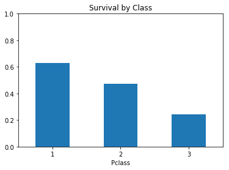

```python
# create plot of survival by class
%pylab inline

class_survival = class_group['Survived'].mean().plot(kind = 'bar', title = "Survival by Class", rot = 1, ylim = [0,1])
```

```python
# Calculate the proportion of passengers in each class that survived:
class_group['Survived'].mean()
```

```
Pclass
1    0.629630
2    0.472826
3    0.242363
Name: Survived, dtype: float64
```

As expected, the highest survival belonged to 1st class, followed by 2nd class. 3rd class passengers were the least likely to survive. Are these differences significant? To test signficance levels, I will use a chi-squre test of independence.

#### Test of signficance

```python
# Create a contingency table
class_contingency = pd.crosstab(titanic_df['Survived'], titanic_df['Pclass'])
class_contingency
```

| Pclass Survived | 1 | 2 | 3 |
| --- | --- | --- | --- |
| 0 | 80 | 97 | 372 |
| 1 | 136 | 87 | 119 |

```python
# Do a chi-square test of independence to test for equality of proportions between populations:
import scipy.stats

scipy.stats.chi2_contingency(class_contingency)
```

```
(102.88898875696056,
 4.5492517112987927e-23,
 2L,
 array([[ 133.09090909,  113.37373737,  302.53535354],
        [  82.90909091,   70.62626263,  188.46464646]]))
```

The above values, in order of appearance, are:

- Χ² value
- p-value
- degrees of freedom
- array of expected values

The sample suggests there is a highly signficant difference between survival rates of 1st, 2nd, and 3rd class passengers (P = 4.5e-23)

## Fare

**Fare** and **Pclass** are most likely highly correlated. Let's first examine this relationship:

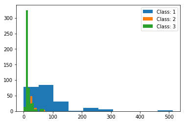

```python
# examine a histogram of fare for each class

import matplotlib.pyplot as plt

def class_fare_plot(df, Pclass):
    class_fares = df[df['Pclass'] == Pclass]['Fare']
    plt.hist(class_fares, label = 'Class: {}'.format(Pclass))

class_fare_plot(titanic_df, 1)
class_fare_plot(titanic_df, 2)
class_fare_plot(titanic_df, 3)

# add a legend
plt.legend(loc = 'upper right')
```

```python
# Examine the fares of people in each passenger class:
class_group['Fare'].describe()
```

| Pclass | count | mean | std | min | 25% | 50% | 75% | max |
| --- | --- | --- | --- | --- | --- | --- | --- | --- |
| 1 | 216.0 | 84.154687 | 78.380373 | 0.0 | 30.92395 | 60.2875 | 93.5 | 512.3292 |
| 2 | 184.0 | 20.662183 | 13.417399 | 0.0 | 13.00000 | 14.2500 | 26.0 | 73.5000 |
| 3 | 491.0 | 13.675550 | 11.778142 | 0.0 | 7.75000 | 8.0500 | 15.5 | 69.5500 |

As expected, 1st class passengers paid higher fares on average than 2nd and 3rd class passengers. 2nd class passengers paid fares more similar to 3rd than 2st class passengers. As we have already seen a relationship between class and survival, we should expect to see the same relationship with **Fare**.

**Out of curiosity, who paid fares of zero dollars?**

```python
titanic_df[titanic_df['Fare'] == 0]
```

|  | PassengerId | Survived | Pclass | Name | Sex | Age | SibSp | Parch | Ticket | Fare | Cabin | Embarked |
| --- | --- | --- | --- | --- | --- | --- | --- | --- | --- | --- | --- | --- |
| 179 | 180 | 0 | 3 | Leonard, Mr. Lionel | male | 36.0 | 0 | 0 | LINE | 0.0 | NaN | S |
| 263 | 264 | 0 | 1 | Harrison, Mr. William | male | 40.0 | 0 | 0 | 112059 | 0.0 | B94 | S |
| 271 | 272 | 1 | 3 | Tornquist, Mr. William Henry | male | 25.0 | 0 | 0 | LINE | 0.0 | NaN | S |
| 277 | 278 | 0 | 2 | Parkes, Mr. Francis "Frank" | male | NaN | 0 | 0 | 239853 | 0.0 | NaN | S |
| 302 | 303 | 0 | 3 | Johnson, Mr. William Cahoone Jr | male | 19.0 | 0 | 0 | LINE | 0.0 | NaN | S |
| 413 | 414 | 0 | 2 | Cunningham, Mr. Alfred Fleming | male | NaN | 0 | 0 | 239853 | 0.0 | NaN | S |
| 466 | 467 | 0 | 2 | Campbell, Mr. William | male | NaN | 0 | 0 | 239853 | 0.0 | NaN | S |
| 481 | 482 | 0 | 2 | Frost, Mr. Anthony Wood "Archie" | male | NaN | 0 | 0 | 239854 | 0.0 | NaN | S |
| 597 | 598 | 0 | 3 | Johnson, Mr. Alfred | male | 49.0 | 0 | 0 | LINE | 0.0 | NaN | S |
| 633 | 634 | 0 | 1 | Parr, Mr. William Henry Marsh | male | NaN | 0 | 0 | 112052 | 0.0 | NaN | S |
| 674 | 675 | 0 | 2 | Watson, Mr. Ennis Hastings | male | NaN | 0 | 0 | 239856 | 0.0 | NaN | S |
| 732 | 733 | 0 | 2 | Knight, Mr. Robert J | male | NaN | 0 | 0 | 239855 | 0.0 | NaN | S |
| 806 | 807 | 0 | 1 | Andrews, Mr. Thomas Jr | male | 39.0 | 0 | 0 | 112050 | 0.0 | A36 | S |
| 815 | 816 | 0 | 1 | Fry, Mr. Richard | male | NaN | 0 | 0 | 112058 | 0.0 | B102 | S |
| 822 | 823 | 0 | 1 | Reuchlin, Jonkheer. John George | male | 38.0 | 0 | 0 | 19972 | 0.0 | NaN | S |

```python
titanic_df[titanic_df['Fare'] == 0].describe()
```

|  | PassengerId | Survived | Pclass | Age | SibSp | Parch | Fare |
| --- | --- | --- | --- | --- | --- | --- | --- |
| count | 15.000000 | 15.000000 | 15.000000 | 7.000000 | 15.0 | 15.0 | 15.0 |
| mean | 516.400000 | 0.066667 | 1.933333 | 35.142857 | 0.0 | 0.0 | 0.0 |
| std | 225.808958 | 0.258199 | 0.798809 | 10.023781 | 0.0 | 0.0 | 0.0 |
| min | 180.000000 | 0.000000 | 1.000000 | 19.000000 | 0.0 | 0.0 | 0.0 |
| 25% | 290.500000 | 0.000000 | 1.000000 | 30.500000 | 0.0 | 0.0 | 0.0 |
| 50% | 482.000000 | 0.000000 | 2.000000 | 38.000000 | 0.0 | 0.0 | 0.0 |
| 75% | 704.000000 | 0.000000 | 2.500000 | 39.500000 | 0.0 | 0.0 | 0.0 |
| max | 823.000000 | 1.000000 | 3.000000 | 49.000000 | 0.0 | 0.0 | 0.0 |

Among those that did not pay any fare, most were 2nd class or higher, and all were males with no close family members on board. Additionally, all boarded at Southamption (S). I wonder if these are invited guests, or if they are perhaps higher level employees?

Also, it is notable that only 1 (6.7%) of the passengers that rode for free survived.

#### Examine the relationship between **Fare** and survival:

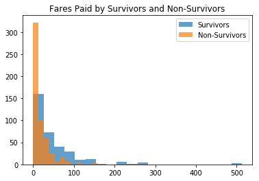

```python
# divide data into survivors and non-survivors. We will use these data frames later as well when we examine other variables.
survivors = titanic_df[titanic_df['Survived'] == 1]
non_survivors = titanic_df[titanic_df['Survived'] == 0]

# create histograms of Fares paid by survivors and non-survivors:
plt.hist(survivors['Fare'], label = 'Survivors', alpha = 0.7, bins = 20)
plt.hist(non_survivors['Fare'], label = 'Non-Survivors', alpha = 0.7, bins = 20)
plt.legend(loc = 'upper right')
plt.title('Fares Paid by Survivors and Non-Survivors')
```

```python
# Descriptive stats on fares paid by survivors and non-survivors
titanic_df.groupby('Survived')['Fare'].describe()
```

| Survived | count | mean | std | min | 25% | 50% | 75% | max |
| --- | --- | --- | --- | --- | --- | --- | --- | --- |
| 0 | 549.0 | 22.117887 | 31.388207 | 0.0 | 7.8542 | 10.5 | 26.0 | 263.0000 |
| 1 | 342.0 | 48.395408 | 66.596998 | 0.0 | 12.4750 | 26.0 | 57.0 | 512.3292 |

Fares paid by survivors tended to be a higher than fares paid by non-survivors.

Would like to do a statistical test. A t-test is not appropriate because the data is highly skewed, and there are some large outliers fare among those that survived.

#### Mann-Whitney Rank Sum Test

To compare fares paid by survivors and non-survivors

```python
# Use mannwhitneyu test from the scipy stats package
scipy.stats.mannwhitneyu(survivors['Fare'], non_survivors['Fare'], alternative = 'greater')
```

```
MannwhitneyuResult(statistic=129951.5, pvalue=2.2767385896251186e-22)
```

A signficant difference (P = 2.3e-22) was found between the fares paid by survivors and non-survivors. Higher fares were associated with higher survival chances.

## Sex

Where women more likely to survive? Is the pattern consistent across different classes?

First, let's group the data by sex, then examine how many passengers of each sex there were:

```python
# group the data by sex
sex_group = titanic_df.groupby('Sex')

# Examine the number of people of each sex:
sex_group['PassengerId'].count()
```

```
Sex
female    314
male      577
Name: PassengerId, dtype: int64
```

Male passengers outnumbered female passengers on the Titanic.

It is also important to consider potential confounding variables:

**What differences are there between the sexes in terms of passenger class and fare?**

```python
# Compare passenger class between males and females
sex_group['Pclass'].describe()
```

| Sex | count | mean | std | min | 25% | 50% | 75% | max |
| --- | --- | --- | --- | --- | --- | --- | --- | --- |
| female | 314.0 | 2.159236 | 0.85729 | 1.0 | 1.0 | 2.0 | 3.0 | 3.0 |
| male | 577.0 | 2.389948 | 0.81358 | 1.0 | 2.0 | 3.0 | 3.0 | 3.0 |

```python
# Compare fares paid between males and females
sex_group['Fare'].describe()
```

| Sex | count | mean | std | min | 25% | 50% | 75% | max |
| --- | --- | --- | --- | --- | --- | --- | --- | --- |
| female | 314.0 | 44.479818 | 57.997698 | 6.75 | 12.071875 | 23.0 | 55.00 | 512.3292 |
| male | 577.0 | 25.523893 | 43.138263 | 0.00 | 7.895800 | 10.5 | 26.55 | 512.3292 |

Females and males belonged to similar classes, with females slightly higher class (median of 2nd class compared to median of 3rd class for males). Females also tended to pay higher fares, consistent with the higher class. I would hypothesize that lower class females were less likely to have the opportunity to sail on the Titanic.

#### How did survivorship vary between the sexes?

Is it greater than what we would expect based on slight differences in class alone?

```python
sex_group['Survived'].describe()
```

| Sex | count | mean | std | min | 25% | 50% | 75% | max |
| --- | --- | --- | --- | --- | --- | --- | --- | --- |
| female | 314.0 | 0.742038 | 0.438211 | 0.0 | 0.0 | 1.0 | 1.0 | 1.0 |
| male | 577.0 | 0.188908 | 0.391775 | 0.0 | 0.0 | 0.0 | 0.0 | 1.0 |

74% 0f female passengers survived, while only 19% of male passengers survived. Here is a bar plot that demonstrates just how large the difference in survival is:

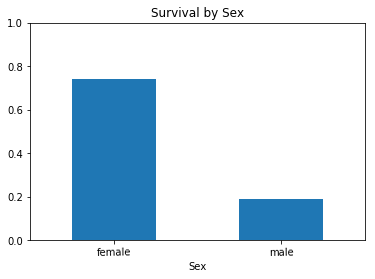

```python
# Plot survival by male and female passengers
sex_group['Survived'].mean().plot(kind = 'bar', title = "Survival by Sex", rot = 1, ylim = [0,1])
```

There is a considerable difference in survival between males and females, even larger than the differences seen by class.

#### Let's look at survival by sex in each class:

```
Sex
female    0.968085
male      0.368852
Name: Survived, dtype: float64
```

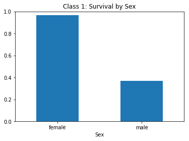

```python
def plot_survival_by_sex(df, Pclass):
    subset = df[df['Pclass'] == Pclass]
    subset.groupby('Sex')['Survived'].mean().plot(kind = 'bar', title = "Class {}: Survival by Sex".format(Pclass), rot = 1, ylim = [0,1])
    print(subset.groupby('Sex')['Survived'].mean())

# First class
plot_survival_by_sex(titanic_df, 1)
```

```
Sex
female    0.921053
male      0.157407
Name: Survived, dtype: float64
```

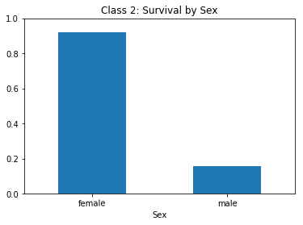

```python
# Second class
plot_survival_by_sex(titanic_df, 2)
```

```
Sex
female    0.500000
male      0.135447
Name: Survived, dtype: float64
```

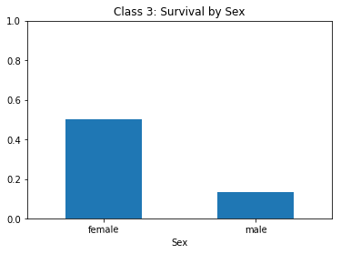

```python
# 3rd class
plot_survival_by_sex(titanic_df, 3)
```

The difference in survival between males and females was highest in 2nd class, with 92% of females surviving and only 16% of males surviving.

1st class males were twice as likely to survive than 2nd class males. In 1st class, 97% of females and 37% of males survived.

In 3rd class, survival was more similar between males and females, with 50% of females surviving and 14% of males surviving. Relative to 1st and 2nd class females, females in 3rd class were only half as likely to survive.

This evidence supports the hypothesis that female survival was prioritized. It also reinforces the previous finding that 3rd class passengers had limited chances of survival.

## Age

Were children prioritized for survival? Are the patterns consistent accross all classes and both sexes?

First, let's examine the distribution of ages:

```python
# What was the distribution of ages?
titanic_df['Age'].describe()
```

```
count    714.000000
mean      29.699118
std       14.526497
min        0.420000
25%       20.125000
50%       28.000000
75%       38.000000
max       80.000000
Name: Age, dtype: float64
```

Median age was 28 years old. About 25% of passengers were 20 years old or younger.

It is also necessary to examine how age varied among the classes and sexes, because these are potentially confounding variables.

**How did ages vary between classes?**

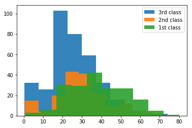

```python
# Because there are some NaNs in the Age column, we need to drop the rows with NaNs before plotting.
# first remove rows where age is NaN
titanic_knownAge = titanic_df.dropna(subset=['Age'], how='all')

class1_ages = titanic_knownAge[titanic_knownAge['Pclass'] == 1]['Age']
class2_ages = titanic_knownAge[titanic_knownAge['Pclass'] == 2]['Age']
class3_ages = titanic_knownAge[titanic_knownAge['Pclass'] == 3]['Age']

# Plot a histogram of the different age classes for each passenger class:
plt.hist(class3_ages, label = '3rd class', alpha = 0.9)
plt.hist(class2_ages, label = '2nd class', alpha = 0.9)
plt.hist(class1_ages, label = '1st class', alpha = 0.9)

plt.legend(loc = 'upper right')
```

3rd class passengers tended to be a younger. Very few 1st class passengers were children.

**Were there differences in age between the genders?**

[figure not shown]

```python
# separate males from females, and drop any rows where age is NaN
female_ages = titanic_knownAge[titanic_knownAge['Pclass'] == 1]['Age']
male_ages = titanic_knownAge[titanic_knownAge['Pclass'] == 2]['Age']

# Create histograms of age classes for males and females:
plt.hist(female_ages, label = 'Females', alpha = 0.9)
plt.hist(male_ages, label = 'Males', alpha = 0.9)

plt.legend(loc = 'upper right')
```

**How did survival differ between the age classes?**

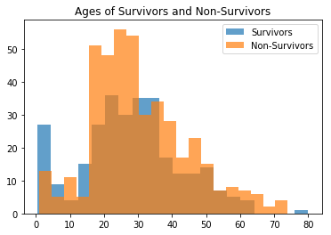

```python
# Plot a histogram of ages for survivors and non-survivors:
plt.hist(survivors['Age'].dropna(), label = 'Survivors', alpha = 0.7, bins = 20)
plt.hist(non_survivors['Age'].dropna(), label = 'Non-Survivors', alpha = 0.7, bins = 20)
plt.legend(loc = 'upper right')
plt.title('Ages of Survivors and Non-Survivors')
```

Children were a bit more likely to survive than adults. Adults aged 20-30 were the least likely to survive. Past age 30, the distributions are similar in age between survivors and non-survivors.

**Let's calculate survival of children under the age of 18, and adults 18 years and older:**

```python
# Colculate the propotion of adults and children that survived:
children = titanic_knownAge[titanic_knownAge['Age'] < 18]
adults = titanic_knownAge[titanic_knownAge['Age'] >= 18]

print("Child (< 18 years) survival:")
print(children['Survived'].mean())

print("Adult (>= 18 years) survival:")
print(adults['Survived'].mean())
```

```
Child (< 18 years) survival:
0.53982300885
Adult (>= 18 years) survival:
0.381031613977
```

#### Is the difference in survival between children and adults signficant?

```python
# Create a contingency table for a chi-square test
isChild_contingency = pd.crosstab(titanic_knownAge['Survived'], titanic_knownAge['Age'] < 18)
isChild_contingency
```

| Age Survived | False | True |
| --- | --- | --- |
| 0 | 372 | 52 |
| 1 | 229 | 61 |

```python
# Do a chi-square test of independence to tst for equality of proportions between populations:
scipy.stats.chi2_contingency(isChild_contingency)
```

```
(9.2960872001350534,
 0.0022964381449624861,
 1L,
 array([[ 356.89635854,   67.10364146],
        [ 244.10364146,   45.89635854]]))
```

The above values, in order of appearance, are:

- Χ² value
- p-value
- degrees of freedom
- array of expected values

The sample suggests there is a signficant difference between survival rates adults and children (P = 0.0023)

**Did sex affect survival of children?**

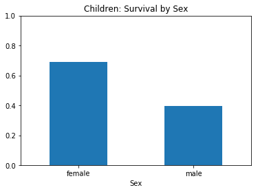

```python
# Create barplot to compare the mean survival of male and female children
children.groupby('Sex')['Survived'].mean().plot(kind = 'bar', title = "Children: Survival by Sex", rot = 1, ylim = [0,1])
```

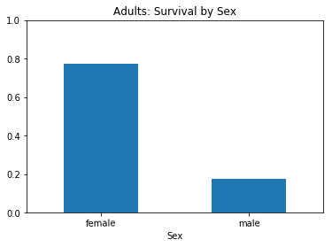

```python
# Create barplot to compare the mean survival of male and female adults
adults.groupby('Sex')['Survived'].mean().plot(kind = 'bar', title = "Adults: Survival by Sex", rot = 1, ylim = [0,1])
```

Sex did appear to affect survival by children, however survival was more similar between the sexes for children than for adults.

## Ticket

Is individal survival independent of the survival of those closest to them? Do people who travel with others survive more often?

**First, let's look at the distribution of number of people per ticket:**

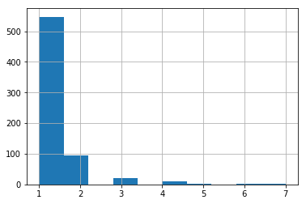

```python
# Create a dataframe of tickets
ticket_group = titanic_df[['Survived', 'Ticket']].groupby('Ticket')

# Calculate the proportion of people on each ticket that survived:
ticket_df = ticket_group.sum()
ticket_df['Count'] = ticket_group.count()
ticket_df['Pct_Survival'] = ticket_df['Survived']/ticket_df['Count']

# Create histogram of the number of people on each ticket
ticket_df['Count'].hist()
```

Most tickets only had one person on them.

**How did survival vary by number of people on a ticket?**

```python
# Aggregate tickets over the number of people on them
ticket_df_group = ticket_df.groupby('Count')
ticket_df_group[['Pct_Survival']].describe()
```

| Count | Pct_Survival count | Pct_Survival mean | Pct_Survival std | Pct_Survival min | Pct_Survival 25% | Pct_Survival 50% | Pct_Survival 75% | Pct_Survival max |
| --- | --- | --- | --- | --- | --- | --- | --- | --- |
| 1 | 547.0 | 0.297989 | 0.457793 | 0.0 | 0.000000 | 0.000000 | 1.000000 | 1.000000 |
| 2 | 94.0 | 0.574468 | 0.407968 | 0.0 | 0.000000 | 0.500000 | 1.000000 | 1.000000 |
| 3 | 21.0 | 0.698413 | 0.296362 | 0.0 | 0.666667 | 0.666667 | 1.000000 | 1.000000 |
| 4 | 11.0 | 0.500000 | 0.387298 | 0.0 | 0.125000 | 0.500000 | 0.750000 | 1.000000 |
| 5 | 2.0 | 0.000000 | 0.000000 | 0.0 | 0.000000 | 0.000000 | 0.000000 | 0.000000 |
| 6 | 3.0 | 0.000000 | 0.000000 | 0.0 | 0.000000 | 0.000000 | 0.000000 | 0.000000 |
| 7 | 3.0 | 0.238095 | 0.412393 | 0.0 | 0.000000 | 0.000000 | 0.357143 | 0.714286 |

It appears that the highest percent survival occurred for tickets with 2-3 people on them. However, there is very sparse data for tickets with more than 4 people on them.

Perhaps we can gain more insight by looking at people who traveled with family members.

## Close Family

Siblings, spouses, parents, children.

Does traveling with family increase survival? Does this extend across classes? Across genders?

First examine numbers of parents and children in each class group:

```python
print("Numbers of parents and children on board for travelers in each passenger class:")
class_group['Parch'].describe()
```

```
Numbers of parents and children on board for travelers in each passenger class:
```

| Pclass | count | mean | std | min | 25% | 50% | 75% | max |
| --- | --- | --- | --- | --- | --- | --- | --- | --- |
| 1 | 216.0 | 0.356481 | 0.693997 | 0.0 | 0.0 | 0.0 | 0.0 | 4.0 |
| 2 | 184.0 | 0.380435 | 0.690963 | 0.0 | 0.0 | 0.0 | 1.0 | 3.0 |
| 3 | 491.0 | 0.393075 | 0.888861 | 0.0 | 0.0 | 0.0 | 0.0 | 6.0 |

The number of parents and children of travelers did not vary much by passenger class

```python
print("Numbers of spouses and sibling on board for travelers in each passenger class:")
class_group['SibSp'].describe()
```

```
Numbers of spouses and sibling on board for travelers in each passenger class:
```

| Pclass | count | mean | std | min | 25% | 50% | 75% | max |
| --- | --- | --- | --- | --- | --- | --- | --- | --- |
| 1 | 216.0 | 0.416667 | 0.611898 | 0.0 | 0.0 | 0.0 | 1.0 | 3.0 |
| 2 | 184.0 | 0.402174 | 0.601633 | 0.0 | 0.0 | 0.0 | 1.0 | 3.0 |
| 3 | 491.0 | 0.615071 | 1.374883 | 0.0 | 0.0 | 0.0 | 1.0 | 8.0 |

Passengers in third class were a bit more likely to travel with a spouse or sibling(s), but not by a large amount.

Does survival change when traveling with family members?

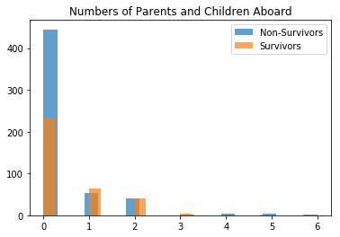

```python
def family_plot(survivors, non_survivors, survivor_column, non_survivor_column, plot_title):
    plt.hist(non_survivor_column, label = 'Non-Survivors', alpha = 0.7, bins = 20)
    plt.hist(survivor_column, label = 'Survivors', alpha = 0.7, bins = 20)
    plt.legend(loc = 'upper right')
    plt.title(plot_title)

# compare number of parents and children aboard for survivors and non-survivors:
family_plot(survivors, non_survivors, survivors['Parch'], non_survivors['Parch'], "Numbers of Parents and Children Aboard")
```

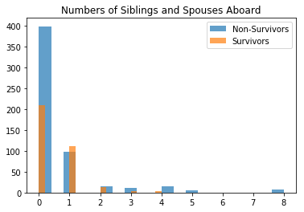

```python
# compare number of siblings and spouses aboard for survivors and non-survivors:
family_plot(survivors, non_survivors, survivors['SibSp'], non_survivors['SibSp'], "Numbers of Siblings and Spouses Aboard")
```

The distributions appear very similar for both spouses/siblings and parents/children. Let's therefore calculate the total number of close family members aboard:

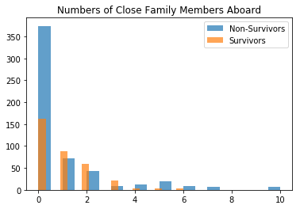

```python
# compare number of family members aboard for survivors and non-survivors:
# First calculate the total number of close family members aboard:
survivor_family = survivors['Parch'] + survivors['SibSp']
non_survivor_family = non_survivors['Parch'] + non_survivors['SibSp']

family_plot(survivors, non_survivors, survivor_family, non_survivor_family, "Numbers of Close Family Members Aboard")
```

Travelers with no close family members aboard are more likely to belong to the non-survivor group.

```python
# Create a contingency table for a chi-square test
family_contingency = pd.crosstab(titanic_df['Survived'], titanic_df['Parch'] + titanic_df['SibSp'])
family_contingency
```

| col_0 Survived | 0 | 1 | 2 | 3 | 4 | 5 | 6 | 7 | 10 |
| --- | --- | --- | --- | --- | --- | --- | --- | --- | --- |
| 0 | 374 | 72 | 43 | 8 | 12 | 19 | 8 | 6 | 7 |
| 1 | 163 | 89 | 59 | 21 | 3 | 3 | 4 | 0 | 0 |

```python
# Do a chi-square test of independence to tst for equality of proportions between populations:
scipy.stats.chi2_contingency(family_contingency)
```

```
(80.67231343783078,
 3.579668975443533e-14,
 8L,
 array([[ 330.87878788,   99.2020202 ,   62.84848485,   17.86868687,
            9.24242424,   13.55555556,    7.39393939,    3.6969697 ,
            4.31313131],
        [ 206.12121212,   61.7979798 ,   39.15151515,   11.13131313,
            5.75757576,    8.44444444,    4.60606061,    2.3030303 ,
            2.68686869]]))
```

The above values, in order of appearance, are:

- Χ² value
- p-value
- degrees of freedom
- array of expected values

#### The sample suggests there is a signficant difference between survival rates of travelers with different numbers of close family members aboard (P = 3.6e-14)

```python
# Calculate the survival rates of passengers with different numbers of close family members aboard
print("Proportion of travelers that survived versus the number of family members they were traveling with:")
family_survival = pd.crosstab(titanic_df['Survived'], titanic_df['Parch'] + titanic_df['SibSp'], normalize='columns')
family_survival.iloc[[1]]
```

```
Proportion of travelers that survived versus the number of family members they were traveling with:
```

| col_0 Survived | 0 | 1 | 2 | 3 | 4 | 5 | 6 | 7 | 10 |
| --- | --- | --- | --- | --- | --- | --- | --- | --- | --- |
| 1 | 0.303538 | 0.552795 | 0.578431 | 0.724138 | 0.2 | 0.136364 | 0.333333 | 0.0 | 0.0 |

We see the same pattern as we saw in number of people per ticket: Survival peaked when traveling with 2-3 family members.

**Does this pattern differ between males and females?**

```python
# Look at survival pattern amongst females
print("Female passengers")
family_survival_females = pd.crosstab(titanic_df[titanic_df['Sex'] == 'female']['Survived'], titanic_df[titanic_df['Sex'] == 'female']['Parch'] + titanic_df['SibSp'], normalize='columns')
family_survival_females.iloc[[1]]
```

[output not shown]

| col_0 Survived | 0.0 | 1.0 | 2.0 | 3.0 | 4.0 | 5.0 | 6.0 | 7.0 | 10.0 |
| --- | --- | --- | --- | --- | --- | --- | --- | --- | --- |
| 1.0 | 0.785714 | 0.816092 | 0.77551 | 0.842105 | 0.25 | 0.375 | 0.375 | 0.0 | 0.0 |

```python
# Look at survival pattern amongst males
print("Male passengers")
family_survival_males = pd.crosstab(titanic_df[titanic_df['Sex'] == 'male']['Survived'], titanic_df[titanic_df['Sex'] == 'male']['Parch'] + titanic_df['SibSp'], normalize='columns')
family_survival_males.iloc[[1]]
```

```
Male passengers
```

| col_0 Survived | 0.0 | 1.0 | 2.0 | 3.0 | 4.0 | 5.0 | 6.0 | 7.0 | 10.0 |
| --- | --- | --- | --- | --- | --- | --- | --- | --- | --- |
| 1.0 | 0.155718 | 0.243243 | 0.396226 | 0.5 | 0.0 | 0.0 | 0.25 | 0.0 | 0.0 |

## Embarked

Investigate whether there is different survival among passengers that embarked from different stations. I do not expect to find a difference. If there is, I would expect it to be due to other differences, such as class, that may be associated with particular stations.

```python
# group by class
embark_group = titanic_df.groupby('Embarked')

# Examine the number of people in each passenger class:
embark_group['PassengerId'].count()
```

```
Embarked
C    168
Q     77
S    644
Name: PassengerId, dtype: int64
```

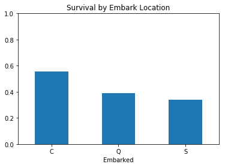

```python
# create plot of survival by class
%pylab inline

embark_group['Survived'].mean().plot(kind = 'bar', title = "Survival by Embark Location", rot = 1, ylim = [0,1])
```

We see slightly higher survival among passengers that embarked from Cherbourg.  
(C = Cherbourg, Q = Queenstown, S = Southampton)

**Where passengers that embarked from Cherbourg more likely to be 2nd or 1st class passengers?**

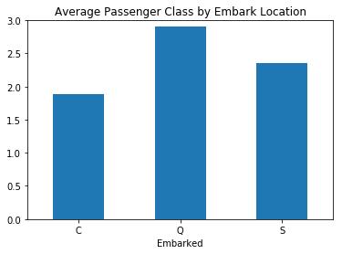

```python
embark_group['Pclass'].mean().plot(kind = 'bar', title = "Average Passenger Class by Embark Location", rot = 1, ylim = [0,3])
```

As suspected, passengers that embarked from Cherbourg were more likely to have a higher class (1st or 2nd), which explains their higher survival rate. Passengers that embarked from Cherbourg also paid higher median fares. I examined median fare instead of average fare because of the few outliers that paid fares over 500.

```python
embark_group['Fare'].median()
```

```
Embarked
C    29.70
Q     7.75
S    13.00
Name: Fare, dtype: float64
```

# Conclusions

Let's revisit the original question and hypotheses:

### What factors made people more likely to survive?

### I found evidence to support all of the original hypotheses:

### **Pclass**:

#### 1st class passengers had the highest survival, followed by 2nd class passengers.

*63% of first class passengers survived, compared to 47% of 2nd class passengers and 24% of 3rd class passengers.*

### **Fare**:

#### Passengers who paid greater fares were more likely to survive.

*Fare was closely associated with passenger class.*

### **Sex**:

#### Female passengers were more likely to survive than male passengers.

*Female survial was prioritized, especially 1st and 2nd class females. In the top two classes, over 90% of females survived, while male survival was less than 40%. Only 50% of female 3rd class passengers survived, but that rate is still higher than survival of 3rd class males (14%)*.

### **SibSp** and **Parch**:

#### Passengers were more likely to survive if they were traveling with their family.

*The same pattern was found for the number of close family members aboard as for number of people on each ticket. Females generally had high survival regardless of the number of family members aboard. Males traveling alone had low survival (16%), while males traveling with 2-3 family members had 40-50% survival.*